# A Guide to Data Visualization

## Introduction

Seaborn is a Python visualization library built on Matplotlib that provides high-level interfaces for creating statistical graphics. It works seamlessly with Pandas DataFrames and is ideal for exploratory data analysis (EDA).

## Why Seaborn?

✔ Built-in themes for better aesthetics  
✔ Simplified syntax for complex plots  
✔ Excellent integration with Pandas  
✔ Statistical visualization capabilities

## 01- Installing libraries

```python
import numpy as np
import pandas as pd
import matplotlib.pyplot as plt
import seaborn as sns
```

## 02- Sample Dataset

```python
import seaborn as sns
tips = sns.load_dataset('tips')
print(tips.head())
```

```
   total_bill   tip     sex smoker  day    time  size
0       16.99  1.01  Female     No  Sun  Dinner     2
1       10.34  1.66    Male     No  Sun  Dinner     3
2       21.01  3.50    Male     No  Sun  Dinner     3
3       23.68  3.31    Male     No  Sun  Dinner     2
4       24.59  3.61  Female     No  Sun  Dinner     4
```

## 03- Key Visualizations

### A. Distribution Plots

Aim: Visualize the distribution of a numeric variable.

1. Histogram

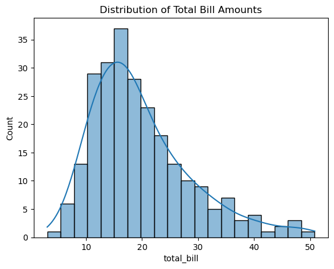

```python
sns.histplot(data=tips, x='total_bill', bins=20, kde=True)
plt.title('Distribution of Total Bill Amounts')
plt.show()
```

- Use: Shows frequency distribution of total_bill.
- Limitations:

Bin size selection can distort interpretation.

Not ideal for small datasets.

2. KDE Plot

```
C:\Users\Yawar Ali\AppData\Local\Temp\ipykernel_9112\1282703512.py:1: FutureWarning:

`shade` is now deprecated in favor of `fill`; setting `fill=True`.
This will become an error in seaborn v0.14.0; please update your code.

  sns.kdeplot(data=tips, x='total_bill', shade=True)
```

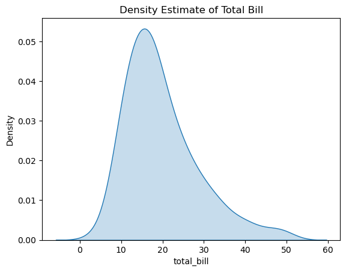

```python
sns.kdeplot(data=tips, x='total_bill', shade=True)
plt.title('Density Estimate of Total Bill')
plt.show()
```

- Use: Smooth version of a histogram.
- Limitations:

Can oversmooth small datasets.

### B. Categorical Plots

Aim: Compare categories.

```
C:\Users\Yawar Ali\AppData\Local\Temp\ipykernel_9112\2704005250.py:1: FutureWarning:

The `ci` parameter is deprecated. Use `errorbar=None` for the same effect.

  sns.barplot(data=tips, x='day', y='total_bill', ci=None)
```

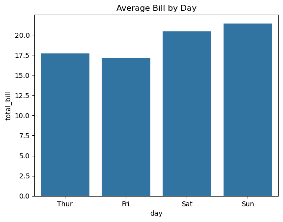

```python
sns.barplot(data=tips, x='day', y='total_bill', ci=None)
plt.title('Average Bill by Day')
plt.show()
```

- Use: Compares means across categories.
- Limitations:

Hides underlying data distribution.

2. Box Plot

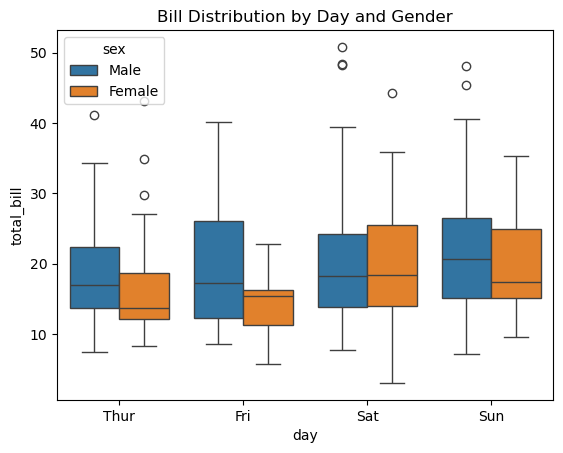

```python
sns.boxplot(data=tips, x='day', y='total_bill', hue='sex')
plt.title('Bill Distribution by Day and Gender')
plt.show()
```

- Use: Shows median, quartiles, and outliers.
- Limitations:

Less intuitive for non-technical audiences.

### C. Relational Plots

Aim: Explore relationships between variables.

1. Scatter Plot

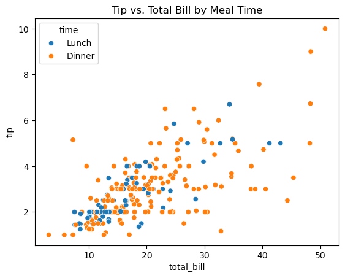

```python
sns.scatterplot(data=tips, x='total_bill', y='tip', hue='time')
plt.title('Tip vs. Total Bill by Meal Time')
plt.show()
```

- Use: Reveals correlations between two numeric variables.
- Limitations:

Overplotting with large datasets

2. Line Plot

```
C:\Users\Yawar Ali\AppData\Local\Temp\ipykernel_9112\3011115773.py:1: FutureWarning:

The `ci` parameter is deprecated. Use `errorbar=('ci', 95)` for the same effect.

  sns.lineplot(data=tips, x='size', y='total_bill', ci=95)
```

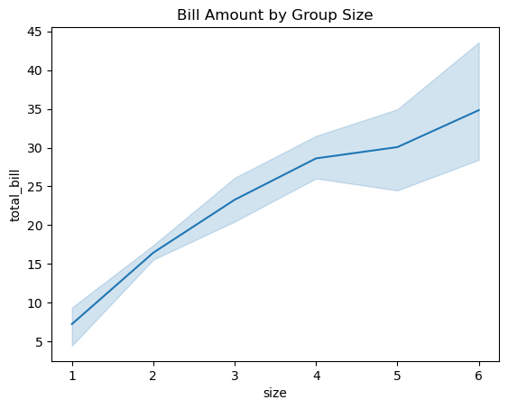

```python
sns.lineplot(data=tips, x='size', y='total_bill', ci=95)
plt.title('Bill Amount by Group Size')
plt.show()
```

- Use: Trends over a continuous variable.
- Limitations:

Assumes ordered data.

D. Matrix Plots

Aim: Visualize matrix-like data.

1. Heatmap

```python
sns.heatmap(tips.corr(), annot=True, cmap='coolwarm')
plt.title('Correlation Matrix')
plt.show()
```

[output not shown]

[output cut: 23 more lines]

[output not shown]

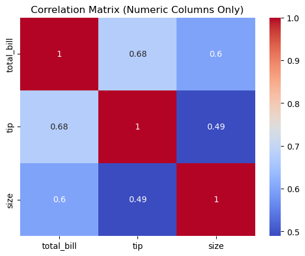

```python
# Calculate correlation for numeric columns only
numeric_tips = tips.select_dtypes(include=['float64', 'int64'])
sns.heatmap(numeric_tips.corr(), annot=True, cmap='coolwarm')
plt.title('Correlation Matrix (Numeric Columns Only)')
plt.show()
```

- Use: Identifies correlations between numeric variables.
- Limitations:

Only works with numeric data.

## 04- Advanced Plots

1. Pair Plot

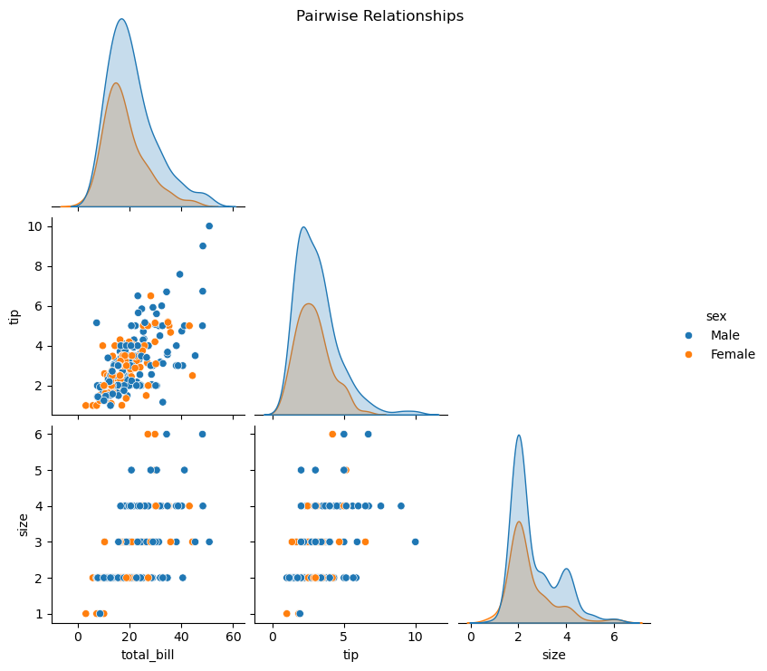

```python
sns.pairplot(tips, hue='sex', corner=True)
plt.suptitle('Pairwise Relationships')
plt.show()
```

- Use: Auto-generates scatter plots for all numeric columns.
- Limitations:

Computationally heavy for large datasets.

2. Violin Plot

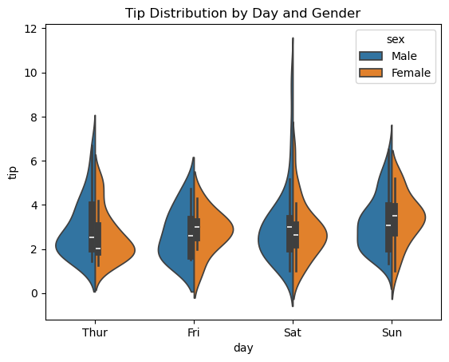

```python
sns.violinplot(data=tips, x='day', y='tip', split=True, hue='sex')
plt.title('Tip Distribution by Day and Gender')
plt.show()
```

- Use: Combines box plot and KDE.
- Limitations:

Can be harder to interpret.

## 05- Customization

```python
# Style and context
sns.set_style('darkgrid')
sns.set_context('talk')

# Color palettes
sns.set_palette('pastel')
```

## 06- Saving Plots

```python
plt.savefig('plot.png', dpi=300, bbox_inches='tight')
```

## 07- Limitations of Seaborn

- Not Interactive: Unlike Plotly, plots are static.
- Limited 3D Support: Primarily for 2D visualizations.
- Steep Learning Curve: Advanced customizations require Matplotlib knowledge.